# Kétszempontos varianciaelemzés

# Példa. A vonzerő és a nem hatása az ítéletekre

> Egy kísérletben a résztvevőket arra kérték, hogy jelöljék meg, hány év börtönbüntetést szabnának ki vádiratok alapján. A 60 résztvevőből 20 egyszerűen megkapta az írásbeli szöveget, nem volt csatolva fotó a vádlottról, 20 résztvevő azonban a szöveg mellé egy vonzó vádlottól származó fotót kapott, az utolsó 20 fős csoport pedig egy nem vonzó vádlottól származót. A fotón férfi vagy nő vádlottak jelentek meg, és a résztvevők közé is egyarán válogattak férfiakat és nőket is.  
> A kísérleti terv tehát 3x2-es elrendezésű, személyek közötti (független) kétszempontos varianciaelemzésnek felel meg. Az első személyek közötti tényező (faktor) az *ismeret a vonzerőről* (vonzerő) volt, amelynek három lehetséges szintje: nincs kép az vádlottról (tehát nem adtak információt a vonzerőről, ez a kontrollcsoport), kép vonzó vádlottról, és kép nem vonzó vádlottról. A másik személyek közötti tényező a *nem egyezése* faktor, amelynek két lehetséges értéke az azonos vagy eltérő nem lehet, attól függgően, hogy a résztvevő neme azonos vagy ellenkező volt az vádlott nemétől. A vádlott nemét a vádiratban jelezték azon résztvevőknek, akik nem kaptak fényképet. A függő változó a résztvevő által kiszabott büntetés, a vádlottnak hány évet kell börtönben töltenie, minimum 3-tól 25-ig. A tesztelt hipotézis az volt, hogy a nem vonzó vádlottakat szigorúbban ítélik meg a résztvevők, illetve az ítélet a résztvevő nemétől is függhet.

Forrás: Brace, Snelgar, and Kemp (2016), 213. o.

## Beolvasás

```r
library(rio)
d <- import(file = "adatok/vallomasok.sav")
dim(d)
```

```
#> [1] 60  3
```

```r
names(d)
```

```
#> [1] "sexdiff"  "attract"  "sentence"
```

```r
library(tibble)
glimpse(d)
```

```
#> Rows: 60
#> Columns: 3
#> $ sexdiff  <dbl> 1, 1, 1, 1, 1, 1, 1, 1, 1, 1, 2, 2, 2, 2, 2, 2, 2, 2, 2, 2...
#> $ attract  <dbl> 1, 1, 1, 1, 1, 1, 1, 1, 1, 1, 1, 1, 1, 1, 1, 1, 1, 1, 1, 1...
#> $ sentence <dbl> 6, 8, 7, 9, 5, 7, 10, 9, 9, 5, 5, 11, 7, 5, 8, 5, 9, 10, 1...
```

## Előkészítés

```r
# faktorrá alakítás
d$sexdiff <- factor(d$sexdiff)
levels(d$sexdiff) <- c("ugyanaz", "eltérő")
d$attract <- factor(d$attract)
levels(d$attract) <- c("vonzó", "nem vonzó", "nincs kép")
```

## Leíró statisztika, mutatók

```r
library(psych)
options(max.print=150)
psych::describeBy(x = d$sentence, group = d[,c("sexdiff", "attract")],
                  mat=T, digits = 2)
```

```
#>     item  group1    group2 vars  n mean   sd median trimmed  mad min max range
#> X11    1 ugyanaz     vonzó    1 10  7.5 1.78    7.5    7.50 2.22   5  10     5
#> X12    2  eltérő     vonzó    1 10  7.5 2.42    7.5    7.38 3.71   5  11     6
#> X13    3 ugyanaz nem vonzó    1 10 11.2 2.30   11.5   11.38 2.97   7  14     7
#> X14    4  eltérő nem vonzó    1 10 10.3 2.06    9.5   10.25 2.22   8  13     5
#> X15    5 ugyanaz nincs kép    1 10 14.5 1.27   14.5   14.50 2.22  13  16     3
#> X16    6  eltérő nincs kép    1 10 13.5 1.65   13.0   13.38 1.48  12  16     4
#>      skew kurtosis   se
#> X11 -0.16    -1.63 0.56
#> X12  0.11    -1.85 0.76
#> X13 -0.37    -1.24 0.73
#> X14  0.33    -1.75 0.65
#> X15  0.00    -1.82 0.40
#> X16  0.47    -1.60 0.52
```

## Leíró statisztika, ábra

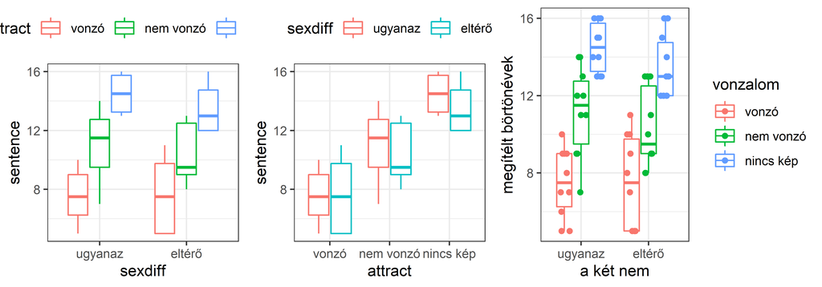

```r
library(ggplot2)
library(gridExtra)

p1 <- ggplot(data=d, aes(x=sexdiff, y=sentence, col=attract)) +
  geom_boxplot() + theme_bw() + theme(legend.position = "top")

p2 <- ggplot(data=d, aes(x=attract, y=sentence, col=sexdiff)) +
  geom_boxplot() + theme_bw() + theme(legend.position = "top")

p3 <- ggplot(data=d,
             aes(x=sexdiff, y=sentence, col=attract)) +
  geom_boxplot() +
  geom_point(position = position_jitterdodge()) +
  theme_bw() +
  theme(legend.position = "right") +
  labs(x="a két nem", y="megítélt börtönévek") +
  scale_color_discrete(name="vonzalom")

grid.arrange(p1, p2, p3, layout_matrix = matrix(rep(1:3, times=c(3,3,4)), nrow=1))
```

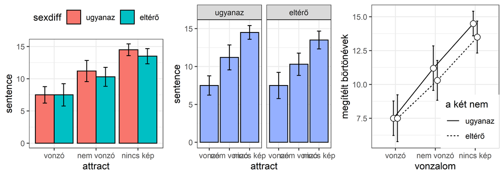

```r
library(ggplot2)
library(gridExtra)

p1 <- ggplot(data=d,
             aes(x=attract, y=sentence, fill=sexdiff)) +
        stat_summary(fun=mean, geom="bar", position="dodge", colour="black") +
        stat_summary(fun.data=mean_cl_normal, geom="errorbar",
                     position=position_dodge(width=0.90), width=0.2) +
        theme_bw() +
        theme(legend.position="top")

p2 <- ggplot(data=d,
             aes(x=attract, y=sentence)) +
        stat_summary(fun=mean, geom="bar", fill="#95b0ff", colour="black") +
        stat_summary(fun.data=mean_cl_normal, geom="errorbar", width=0.2) +
        theme_bw() +
        facet_wrap(~sexdiff, nrow = 1)

pd <- position_dodge(width = 0.2)
p3 <- ggplot(data=d,
       aes(x=attract, y=sentence, group=sexdiff)) +
  stat_summary(fun.data=mean_cl_normal,
               geom="line",
               aes(linetype=sexdiff),
               position = pd) +
  stat_summary(fun.data=mean_cl_normal,
               geom="errorbar",
               width=0.1,
               position = pd) +
  stat_summary(fun=mean, geom="point",
               size=3,
               fill="white",
               shape=21,
               position = pd) +
  theme_bw() +
  theme(legend.justification=c(1,0),legend.position=c(1,0)) +
  scale_linetype_discrete(name="a két nem") +
  labs(x="vonzalom", y="megítélt börtönévek")


grid.arrange(p1, p2, p3, nrow=1)
```

## Előfeltétel vizsgálata

```r
d.lm <- lm(sentence~sexdiff*attract, data=d)
shapiro.test(residuals(d.lm))  # normalitás a reziduálisra
```

```
#>
#>  Shapiro-Wilk normality test
#>
#> data:  residuals(d.lm)
#> W = 0.94977, p-value = 0.01519
```

```r
aggregate(d$sentence, d[,c("sexdiff", "attract")], function(x) shapiro.test(x)$p.value)
```

```
#>   sexdiff   attract          x
#> 1 ugyanaz     vonzó 0.33539316
#> 2  eltérő     vonzó 0.06225668
#> 3 ugyanaz nem vonzó 0.52839183
#> 4  eltérő nem vonzó 0.04386552
#> 5 ugyanaz nincs kép 0.06067448
#> 6  eltérő nincs kép 0.03019355
```

```r
library(DescTools)
LeveneTest(sentence~sexdiff*attract, data=d, center="mean")
```

```
#> Levene's Test for Homogeneity of Variance (center = "mean")
#>       Df F value Pr(>F)
#> group  5  1.5087 0.2025
#>       54
```

## Próba végrehajtása

```r
# három módszer létezik: Type I, Type II, Type III
# kiegyensúlyozott esetben (azonos elemszámú csoportok esetén) azonos eredményt adnak
# http://goanna.cs.rmit.edu.au/~fscholer/anova.php

# Type I. - ne használjuk kiegyensúlyozatlan elrendezés estén
d.aov <- aov(sentence~sexdiff*attract, data=d)
summary(d.aov)
```

```
#>                 Df Sum Sq Mean Sq F value  Pr(>F)
#> sexdiff          1    6.0    6.02   1.579   0.214
#> attract          2  422.5  211.25  55.457 8.1e-14 ***
#> sexdiff:attract  2    3.0    1.52   0.398   0.674
#> Residuals       54  205.7    3.81
#> ---
#> Signif. codes:  0 '***' 0.001 '**' 0.01 '*' 0.05 '.' 0.1 ' ' 1
```

```r
# hatásmértékek
library(sjstats)
eta_sq(model = d.aov)
```

```
#>              term etasq
#> 1         sexdiff 0.009
#> 2         attract 0.663
#> 3 sexdiff:attract 0.005
```

```r
eta_sq(model = d.aov, partial = T)
```

```
#>              term partial.etasq
#> 1         sexdiff         0.028
#> 2         attract         0.673
#> 3 sexdiff:attract         0.015
```

```r
omega_sq(model = d.aov)
```

```
#>              term omegasq
#> 1         sexdiff   0.003
#> 2         attract   0.647
#> 3 sexdiff:attract  -0.007
```

```r
# Type II - feltételezett interakció nélküli eseteben használjuk
d.lm <- lm(sentence~sexdiff*attract, data=d)
car::Anova(d.lm, type="II")
```

```
#> Anova Table (Type II tests)
#>
#> Response: sentence
#>                 Sum Sq Df F value    Pr(>F)
#> sexdiff           6.02  1  1.5795    0.2142
#> attract         422.50  2 55.4570 8.104e-14 ***
#> sexdiff:attract   3.03  2  0.3982    0.6735
#> Residuals       205.70 54
#> ---
#> Signif. codes:  0 '***' 0.001 '**' 0.01 '*' 0.05 '.' 0.1 ' ' 1
```

```r
# hatásmérték
eta_sq(model = car::Anova(d.lm, type="II"))
```

```
#>              term etasq
#> 1         sexdiff 0.009
#> 2         attract 0.663
#> 3 sexdiff:attract 0.005
```

```r
eta_sq(model = car::Anova(d.lm, type="II"), partial = T)
```

```
#>              term partial.etasq
#> 1         sexdiff         0.028
#> 2         attract         0.673
#> 3 sexdiff:attract         0.015
```

```r
omega_sq(model = car::Anova(d.lm, type="II"))
```

```
#>              term omegasq
#> 1         sexdiff   0.003
#> 2         attract   0.647
#> 3 sexdiff:attract  -0.007
```

```r
# Type III - feltételezett interakció esetén használjuk
d.lm <- lm(sentence~sexdiff*attract, data=d,
           contrasts=list(sexdiff=contr.sum,
                          attract=contr.sum))
car::Anova(d.lm, type="III")
```

```
#> Anova Table (Type III tests)
#>
#> Response: sentence
#>                 Sum Sq Df   F value    Pr(>F)
#> (Intercept)     6933.8  1 1820.2358 < 2.2e-16 ***
#> sexdiff            6.0  1    1.5795    0.2142
#> attract          422.5  2   55.4570 8.104e-14 ***
#> sexdiff:attract    3.0  2    0.3982    0.6735
#> Residuals        205.7 54
#> ---
#> Signif. codes:  0 '***' 0.001 '**' 0.01 '*' 0.05 '.' 0.1 ' ' 1
```

```r
# hatásmértékek
eta_sq(model = car::Anova(d.lm, type="III"))
```

```
#>              term etasq
#> 2         sexdiff 0.009
#> 3         attract 0.663
#> 4 sexdiff:attract 0.005
```

```r
eta_sq(model = car::Anova(d.lm, type="III"), partial = T)
```

```
#>              term partial.etasq
#> 2         sexdiff         0.028
#> 3         attract         0.673
#> 4 sexdiff:attract         0.015
```

```r
omega_sq(model = car::Anova(d.lm, type="III"))
```

```
#>              term omegasq
#> 2         sexdiff   0.003
#> 3         attract   0.647
#> 4 sexdiff:attract  -0.007
```

```r
# minden egyben
anova_stats(car::Anova(d.lm, type="III"))
```

```
#>                            term   sumsq  meansq df statistic p.value etasq
#> sexdiff                 sexdiff   6.017   6.017  1     1.579   0.214 0.009
#> attract                 attract 422.500 211.250  2    55.457   0.000 0.663
#> sexdiff:attract sexdiff:attract   3.033   1.517  2     0.398   0.674 0.005
#> ...4                  Residuals 205.700   3.809 54        NA      NA    NA
#>                 partial.etasq omegasq partial.omegasq epsilonsq cohens.f power
#> sexdiff                 0.028   0.003           0.010     0.003    0.171 0.242
#> attract                 0.673   0.647           0.645     0.651    1.433 1.000
#> sexdiff:attract         0.015  -0.007          -0.020    -0.007    0.121 0.115
#> ...4                       NA      NA              NA        NA       NA    NA
```

```r
# utóvizsgálat
pairwise.t.test(x = d$sentence, g = d$attract, p.adjust.method = "bonf")
```

```
#>
#>  Pairwise comparisons using t tests with pooled SD
#>
#> data:  d$sentence and d$attract
#>
#>           vonzó   nem vonzó
#> nem vonzó 6.0e-06 -
#> nincs kép 1.3e-14 6.0e-06
#>
#> P value adjustment method: bonferroni
```

## Szöveges értékelés

Kétszempontos (független, személyek közötti) varianciaelemzést hajtottunk végre a börtönévek kiszabásával kapcsolatban. A nem (vagyis a résztvevő nemének egyezése vagy különbözősége az alperes nemével) esetében nem tudtunk kimutatni szignifikáns hatást a börtönbüntetés súlyosságára nézve ($F(1,54)=1,58; p=0,214; \eta^2=0,009$). Azonban a vádlott vonzóságára vonatkozó információnak szignifikáns főhatása van a kiszabott büntetésre ($F(2,54)=55,46;p<0,001; \eta^2=0,663$). A két faktor között nincs interakció ($F(2,54)=0,40;p=0,674;\eta^2=0,005$). A szignifikáns főhatást mutató vonzalom faktorra utóvizsgálatot hajtottunk végre, páronkénti összehasonlítást Bonferroni korrekcióval. Szignifikáns eltérést találtunk a mindhárom pár esetében ($p<0,001$). A legsúlyosabb büntetésre tehát a kép nélküli esetben számíthatunk, a legenyhébbre pedig a vonzó fénykép esetén.

## Alternatívák

```
#>
#>  ANOVA
#>
#>  ANOVA - sentence
#>  ¦¦¦¦¦¦¦¦¦¦¦¦¦¦¦¦¦¦¦¦¦¦¦¦¦¦¦¦¦¦¦¦¦¦¦¦¦¦¦¦¦¦¦¦¦¦¦¦¦¦¦¦¦¦¦¦¦¦¦¦¦¦¦¦¦¦¦¦¦¦¦¦¦¦¦¦¦¦¦¦¦¦¦¦¦¦¦¦¦¦¦¦¦¦¦¦¦¦¦¦¦¦¦¦¦¦¦¦¦¦¦¦¦¦¦¦¦¦¦¦¦¦¦¦¦¦
#>                       Sum of Squares    df    Mean Square    F             p             η2           η2p          ω2
#>  ¦¦¦¦¦¦¦¦¦¦¦¦¦¦¦¦¦¦¦¦¦¦¦¦¦¦¦¦¦¦¦¦¦¦¦¦¦¦¦¦¦¦¦¦¦¦¦¦¦¦¦¦¦¦¦¦¦¦¦¦¦¦¦¦¦¦¦¦¦¦¦¦¦¦¦¦¦¦¦¦¦¦¦¦¦¦¦¦¦¦¦¦¦¦¦¦¦¦¦¦¦¦¦¦¦¦¦¦¦¦¦¦¦¦¦¦¦¦¦¦¦¦¦¦¦¦
#>    sexdiff                  6.016667     1       6.016667     1.5794847     0.2142442    0.0094416    0.0284185     0.0034434
#>    attract                422.500000     2     211.250000    55.4569762    < .0000001    0.6630051    0.6725565     0.6471812
#>    sexdiff:attract          3.033333     2       1.516667     0.3981526     0.6735146    0.0047600    0.0145321    -0.0071525
#>    Residuals              205.700000    54       3.809259
#>  ¦¦¦¦¦¦¦¦¦¦¦¦¦¦¦¦¦¦¦¦¦¦¦¦¦¦¦¦¦¦¦¦¦¦¦¦¦¦¦¦¦¦¦¦¦¦¦¦¦¦¦¦¦¦¦¦¦¦¦¦¦¦¦¦¦¦¦¦¦¦¦¦¦¦¦¦¦¦¦¦¦¦¦¦¦¦¦¦¦¦¦¦¦¦¦¦¦¦¦¦¦¦¦¦¦¦¦¦¦¦¦¦¦¦¦¦¦¦¦¦¦¦¦¦¦¦
#>
#>
#>  ASSUMPTION CHECKS
#>
#>  Homogeneity of Variances Test (Levene's)
#>  ¦¦¦¦¦¦¦¦¦¦¦¦¦¦¦¦¦¦¦¦¦¦¦¦¦¦¦¦¦¦¦¦¦¦¦¦¦¦¦¦
#>    F           df1    df2    p
#>  ¦¦¦¦¦¦¦¦¦¦¦¦¦¦¦¦¦¦¦¦¦¦¦¦¦¦¦¦¦¦¦¦¦¦¦¦¦¦¦¦
#>    1.508723      5     54    0.2024876
#>  ¦¦¦¦¦¦¦¦¦¦¦¦¦¦¦¦¦¦¦¦¦¦¦¦¦¦¦¦¦¦¦¦¦¦¦¦¦¦¦¦
#>
#>
#>  Normality Test (Shapiro-Wilk)
#>  ¦¦¦¦¦¦¦¦¦¦¦¦¦¦¦¦¦¦¦¦¦¦¦¦¦¦¦¦¦
#>    Statistic    p
#>  ¦¦¦¦¦¦¦¦¦¦¦¦¦¦¦¦¦¦¦¦¦¦¦¦¦¦¦¦¦
#>    0.9497686    0.0151904
#>  ¦¦¦¦¦¦¦¦¦¦¦¦¦¦¦¦¦¦¦¦¦¦¦¦¦¦¦¦¦
#>
#>
#>  POST HOC TESTS
#>
#>  Post Hoc Comparisons - attract
#>  ¦¦¦¦¦¦¦¦¦¦¦¦¦¦¦¦¦¦¦¦¦¦¦¦¦¦¦¦¦¦¦¦¦¦¦¦¦¦¦¦¦¦¦¦¦¦¦¦¦¦¦¦¦¦¦¦¦¦¦¦¦¦¦¦¦¦¦¦¦¦¦¦¦¦¦¦¦¦¦¦¦¦¦¦¦¦¦¦¦¦¦¦¦¦¦¦¦¦¦¦¦¦¦¦¦¦¦¦¦¦¦¦¦¦¦¦¦¦¦¦¦¦¦¦¦¦¦¦¦¦¦¦¦¦¦¦¦¦¦¦¦¦¦¦¦¦¦¦¦¦¦¦¦¦¦¦¦¦¦¦
#>    attract           attract      Mean Difference    SE           df          t             p-tukey       p-scheffe     p-bonferroni    p-holm        Cohen's d
#>  ¦¦¦¦¦¦¦¦¦¦¦¦¦¦¦¦¦¦¦¦¦¦¦¦¦¦¦¦¦¦¦¦¦¦¦¦¦¦¦¦¦¦¦¦¦¦¦¦¦¦¦¦¦¦¦¦¦¦¦¦¦¦¦¦¦¦¦¦¦¦¦¦¦¦¦¦¦¦¦¦¦¦¦¦¦¦¦¦¦¦¦¦¦¦¦¦¦¦¦¦¦¦¦¦¦¦¦¦¦¦¦¦¦¦¦¦¦¦¦¦¦¦¦¦¦¦¦¦¦¦¦¦¦¦¦¦¦¦¦¦¦¦¦¦¦¦¦¦¦¦¦¦¦¦¦¦¦¦¦¦
#>    vonzo        -    nem vonzo          -3.250000    0.6171920    54.00000     -5.265785     0.0000074     0.0000138       0.0000074     0.0000050    0.6798099
#>                 -    nincs kep          -6.500000    0.6171920    54.00000    -10.531569    < .0000001    < .0000001    < .0000001    < .0000001    1.3596198
```

[output cut: 12 more lines]

```
#>    vonzo         7.500000    0.4364206     6.625029     8.374971
#>    nem vonzo    10.750000    0.4364206     9.875029    11.624971
#>    nincs kep    14.000000    0.4364206    13.125029    14.874971
#>  ¦¦¦¦¦¦¦¦¦¦¦¦¦¦¦¦¦¦¦¦¦¦¦¦¦¦¦¦¦¦¦¦¦¦¦¦¦¦¦¦¦¦¦¦¦¦¦¦¦¦¦¦¦¦¦¦¦¦¦¦¦¦¦¦¦
#>
#>
#>  SEXDIFF
#>
#>  Estimated Marginal Means - sexdiff
#>  ¦¦¦¦¦¦¦¦¦¦¦¦¦¦¦¦¦¦¦¦¦¦¦¦¦¦¦¦¦¦¦¦¦¦¦¦¦¦¦¦¦¦¦¦¦¦¦¦¦¦¦¦¦¦¦¦¦¦¦¦¦
#>    sexdiff    Mean        SE           Lower        Upper
#>  ¦¦¦¦¦¦¦¦¦¦¦¦¦¦¦¦¦¦¦¦¦¦¦¦¦¦¦¦¦¦¦¦¦¦¦¦¦¦¦¦¦¦¦¦¦¦¦¦¦¦¦¦¦¦¦¦¦¦¦¦¦
#>    ugyanaz    11.06667    0.3563359    10.352256    11.78108
#>    eltero     10.43333    0.3563359     9.718923    11.14774
#>  ¦¦¦¦¦¦¦¦¦¦¦¦¦¦¦¦¦¦¦¦¦¦¦¦¦¦¦¦¦¦¦¦¦¦¦¦¦¦¦¦¦¦¦¦¦¦¦¦¦¦¦¦¦¦¦¦¦¦¦¦¦
```

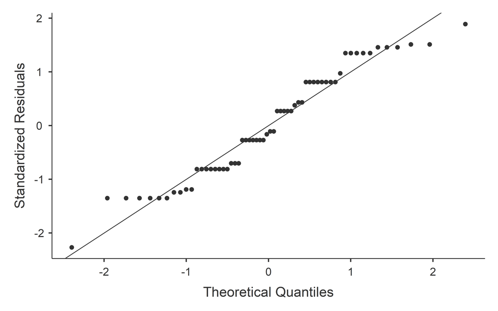

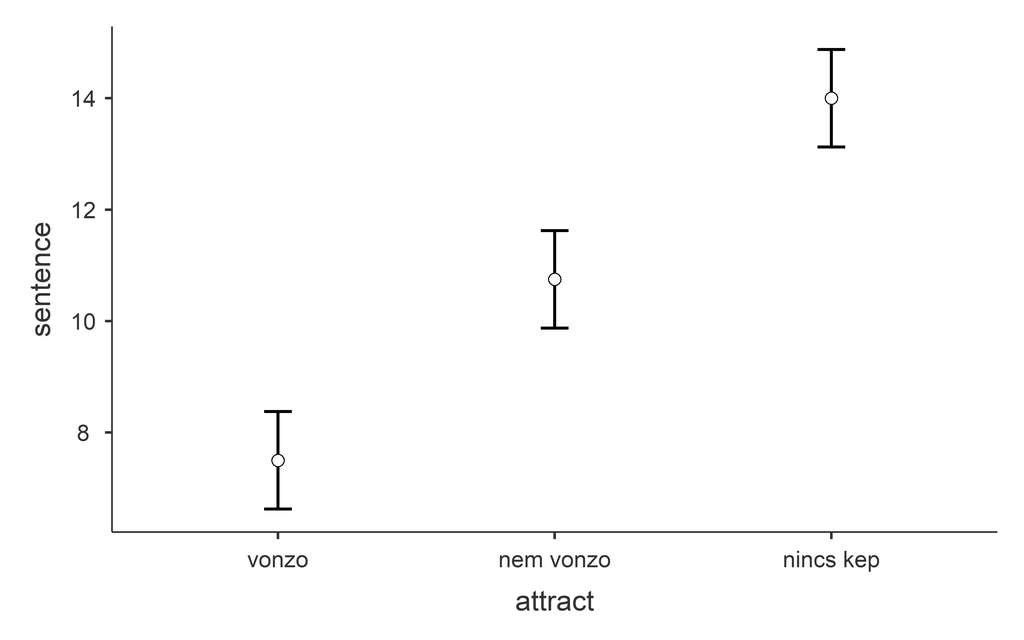

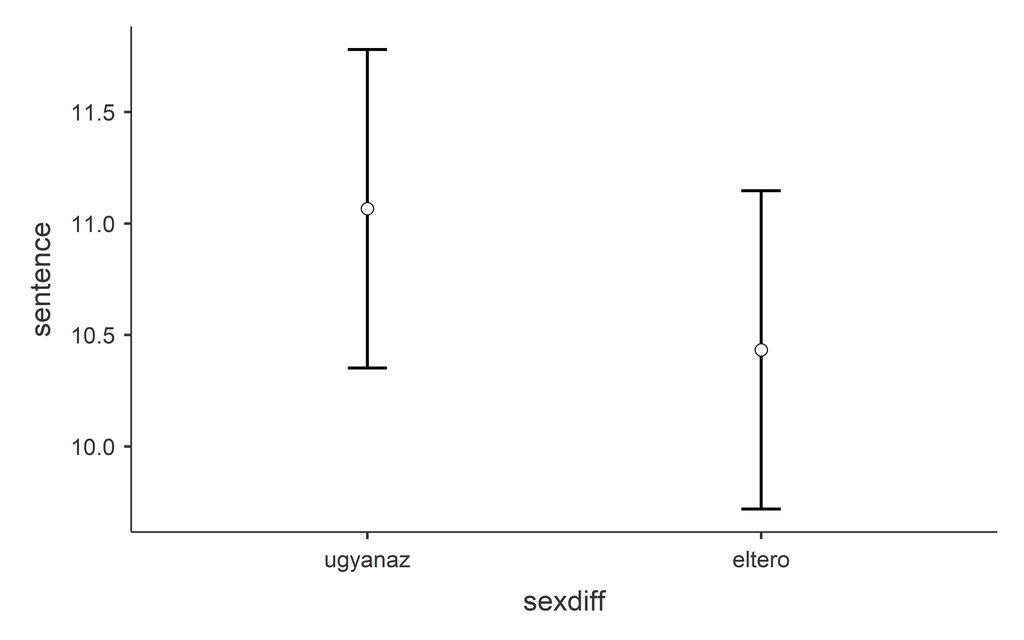

```r
library(jmv)
levels(d$sexdiff) <- c("ugyanaz", "eltero")
levels(d$attract) <- c("vonzo", "nem vonzo", "nincs kep")
jmv::ANOVA(
    formula = sentence ~ sexdiff + attract + sexdiff:attract,
    data = d,
    effectSize = c("eta", "partEta", "omega"),
    homo = TRUE,
    norm = TRUE,
    qq = TRUE,
    postHoc = ~ attract,
    postHocCorr = c("tukey", "scheffe", "bonf", "holm"),
    postHocES = "d",
    emMeans = ~ attract + sexdiff,
    emmTables = TRUE)
```

# Irodalom

Brace, Nicola, Rosemary Snelgar, and Richard Kemp. 2016. *SPSS for Psychologists: And Everybody Else*. Red Globe Press.